# [프로젝트] 법률 문서 기반 검색 에이전트

# 4. Agent RAG 구현

- 각 법률에 특화된 RAG 에이전트를 구현
- 질문 라우팅을 통해서 각 에이전트를 도구 형태로 사용
- 생성된 답변에 대한 피드백을 제공하는 에이전트 사용
- 필요한 경우 사람의 피드백을 요청 (답변이 애매한 경우 - 재검색 여부 판단)

### 4-1. 각 법률에 특화된 RAG 에이전트를 구현

- 검색된 문서의 관련성 등을 평가하여 질문 재작성 및 다시 검색 (Corrective RAG 적용)

`(1) 개인정보보호법 검색 에이전트`

```python
from pydantic import BaseModel, Field
from typing import List, TypedDict, Optional, Annotated, Literal
from langchain_core.documents import Document
import operator

class CorrectiveRagState(TypedDict):
    """Corrective RAG 워크플로우의 기본 상태 정의

    Attributes:
        question: 사용자의 원본 질문
        generation: LLM이 생성한 답변
        documents: 검색된 컨텍스트 문서 리스트
        num_generations: 답변 생성 횟수 (무한 루프 방지용, 최대 3회 권장)
        user_decision: 사용자의 답변 승인/거부 결정
        user_feedback: 거부 시 사용자가 제공하는 구체적인 피드백
    """
    question: str                 # 사용자의 질문
    generation: str               # LLM 생성 답변
    documents: List[Document]     # 컨텍스트 문서 (검색된 문서)
    num_generations: int          # 질문 or 답변 생성 횟수 (무한 루프 방지에 활용)
    user_decision: Literal["rejected", "accepted"]  # 사용자 결정 (거부 or 수락)
    user_feedback: Optional[str]  # 사용자 피드백 (구체적인 피드백을 제공할 수 있는 경우)

class InformationStrip(BaseModel):
    """추출된 정보에 대한 내용과 출처, 관련성 점수

    문서에서 추출된 개별 정보 조각을 표현하며,
    관련성과 충실성 점수를 통해 정보의 품질을 평가합니다.
    """
    content: str = Field(description="추출된 정보 내용")
    source: str = Field(description="정보의 출처(법률 조항 또는 URL 등). 예시: 환경법 제22조 3항 or 블로그 환경법 개정 (https://blog.com/page/123)")
    relevance_score: float = Field(description="관련성 점수 (0에서 1 사이)")
    faithfulness_score: float = Field(description="충실성 점수 (0에서 1 사이)")

class ExtractedInformation(BaseModel):
    """문서에서 추출된 정보 집합

    여러 정보 조각(strips)과 전반적인 답변 가능성 점수를 포함합니다.
    """
    strips: List[InformationStrip] = Field(description="추출된 정보 조각들")
    query_relevance: float = Field(description="질의에 대한 전반전인 답변 가능성 점수 (0에서 1 사이)")

class RefinedQuestion(BaseModel):
    """개선된 질문과 이유

    원본 질문의 모호함이나 부족한 점을 보완한 재작성된 질문입니다.
    """
    question_refined : str = Field(description="개선된 질문")
    reason : str = Field(description="이유")

# PersonalRagState - 병렬 처리를 지원
class PersonalRagState(CorrectiveRagState):
    """개인정보보호법 RAG 에이전트 상태

    CorrectiveRagState를 확장하여 병렬 문서 처리(Map-Reduce)를 지원합니다.
    Annotated[List, operator.add]를 사용하여 병렬 워커의 결과를 자동 병합합니다.
    """
    rewritten_query: str   # 재작성한 질문
    extracted_info: Annotated[List[InformationStrip], operator.add]  # 병렬 워커 작업용
    processed_info: List[InformationStrip]  # 후처리된 결과용
    node_answer: Optional[str]

# 개별 문서 처리를 위한 워커 상태
class DocumentWorkerState(TypedDict):
    """Map-Reduce 패턴의 개별 문서 처리 워커 상태

    Send 객체를 통해 각 문서를 개별 워커로 전달할 때 사용됩니다.
    병렬 처리된 결과는 operator.add 리듀서로 자동 병합됩니다.
    """
    document: str  # 단일 문서
    question: str  # 질문
    # 워커에서도 동일한 타입으로 반환
    extracted_info: Annotated[List[InformationStrip], operator.add]
```

```python
from langchain_core.prompts import ChatPromptTemplate, MessagesPlaceholder
from langgraph.types import Send

def retrieve_documents(state: PersonalRagState) -> PersonalRagState:
    print("---개인정보보호법 문서 검색---")
    query = state.get("rewritten_query", state["question"])
    docs = personal_law_search.invoke(query)
    return {"documents": docs}

def create_evaluation_workers(state: PersonalRagState):
    """각 문서에 대해 평가 작업을 수행하는 병렬 워커를 생성하는 조건부 엣지 함수"""
    print(f"---개인정보보호법 관련 {len(state['documents'])}개 문서에 대한 평가 병렬 워커 생성---")

    # 각 문서에 대해 Send 객체를 생성하여 병렬 처리
    return [
        Send("evaluate_single_document", {
            "document": doc.page_content,
            "question": state["question"],
            "user_feedback": state.get("user_feedback", ""),  # 사용자 피드백이 있는 경우 전달
        })
        for doc in state["documents"]
    ]

def evaluate_single_document(state: DocumentWorkerState) -> PersonalRagState:
    """단일 문서를 처리하는 워커 함수"""
    print(f"---개인정보보호법 단일 문서 처리 중 (길이: {len(state['document'])}...)---")

    # 프롬프트 템플릿 정의
    extract_prompt = ChatPromptTemplate.from_messages([
        ("system", """당신은 개인정보보호법 전문가입니다. 주어진 문서에서 질문과 관련된 주요 사실과 정보를 3~5개 정도 추출하세요.

        각 추출된 정보에 대해 다음 두 가지 측면을 0에서 1 사이의 점수로 평가하세요:
        1. 질문과의 관련성
        2. 답변의 충실성 (질문에 대한 완전하고 정확한 답변을 제공할 수 있는 정도)

        추출 형식:
        1. [추출된 정보]
        - 관련성 점수: [0-1 사이의 점수]
        - 충실성 점수: [0-1 사이의 점수]
        2. [추출된 정보]
        - 관련성 점수: [0-1 사이의 점수]
        - 충실성 점수: [0-1 사이의 점수]
        ...

        마지막으로, 추출된 정보를 종합하여 질문에 대한 전반적인 답변 가능성을 0에서 1 사이의 점수로 평가하세요."""),
        MessagesPlaceholder("user_feedback"),
        ("human", "<질문>\n{question}\n</질문>\n<문서 내용>\n{document_content}\n</문서 내용>")
    ])

    # LLM 호출
    extract_llm = llm.with_structured_output(ExtractedInformation)

    try:
        extracted_data = extract_llm.invoke(extract_prompt.format(
            question=state["question"],
            document_content=state["document"],
            user_feedback=[("system", f"정보를 추출할 때 다음 사용자 피드백을 고려하세요:\n<피드백>{state['user_feedback']}</피드백>")] if "user_feedback" in state else []
        ))

        # 품질 필터링
        if extracted_data.query_relevance < 0.8:
            print(f"문서 관련성이 낮음: {extracted_data.query_relevance}")
            return {"extracted_info": []}

        # 고품질 정보만 필터링
        high_quality_strips = [
            strip for strip in extracted_data.strips
            if strip.relevance_score > 0.7 and strip.faithfulness_score > 0.7
        ]

        print(f"고품질 정보 {len(high_quality_strips)}개 추출됨")
        return {"extracted_info": high_quality_strips}

    except Exception as e:
        print(f"문서 처리 중 오류 발생: {e}")
        return {"extracted_info": []}

def aggregate_results(state: PersonalRagState) -> PersonalRagState:
    """병렬 처리된 결과를 집계하는 함수"""
    print(f"---개인정보보호법 관련 총 {len(state['extracted_info'])}개의 정보 조각 집계---")

    # 후처리가 필요한 경우에만 작업 추가

    # 방법 1: 중복 제거
    unique_strips = []
    seen_content = set()
    for strip in state["extracted_info"]:
        if strip.content not in seen_content:
            unique_strips.append(strip)
            seen_content.add(strip.content)

    # 방법 2: 품질순 정렬
    sorted_strips = sorted(
        unique_strips,
        key=lambda x: (x.relevance_score + x.faithfulness_score) / 2,
        reverse=True
    )

    # 방법 3: 상위 N개만 선택
    top_strips = sorted_strips[:10]  # 상위 10개만

    return {
        "num_generations": state.get("num_generations", 0) + 1,
        "processed_info": top_strips  # 후처리된 결과
    }
```

```python
# 쿼리 재작성 함수
def rewrite_query(state: PersonalRagState) -> PersonalRagState:
    print("---개인정보보호법 쿼리 재작성---")

    rewrite_prompt = ChatPromptTemplate.from_messages([
        ("system", """당신은 개인정보보호법 전문가입니다. 주어진 원래 질문과 추출된 정보를 바탕으로, 더 관련성 있고 충실한 정보를 찾기 위해 검색 쿼리를 개선해주세요.

        다음 사항을 고려하여 검색 쿼리를 개선하세요:
        1. 원래 질문의 핵심 요소
        2. 추출된 정보의 관련성 점수
        3. 추출된 정보의 충실성 점수
        4. 부족한 정보나 더 자세히 알아야 할 부분

        개선된 검색 쿼리 작성 단계:
        1. 2-3개의 검색 쿼리를 제안하세요.
        2. 각 쿼리는 구체적이고 간결해야 합니다(5-10 단어 사이).
        3. 개인정보보호법과 관련된 전문 용어를 적절히 활용하세요.
        4. 각 쿼리 뒤에는 해당 쿼리를 제안한 이유를 간단히 설명하세요.

        출력 형식:
        1. [개선된 검색 쿼리 1]
        - 이유: [이 쿼리를 제안한 이유 설명]
        2. [개선된 검색 쿼리 2]
        - 이유: [이 쿼리를 제안한 이유 설명]
        3. [개선된 검색 쿼리 3]
        - 이유: [이 쿼리를 제안한 이유 설명]

        마지막으로, 제안된 쿼리 중 가장 효과적일 것 같은 쿼리를 선택하고 그 이유를 설명하세요."""),
        MessagesPlaceholder("user_feedback"),
        ("human", "<원래 질문>\n{question}\n</원래 질문>\n<추출된 정보>\n{processed_info}\n</추출된 정보>\n\n위 지침에 따라 개선된 검색 쿼리를 작성해주세요.")
    ])

    processed_info_str = "\n".join([strip.content for strip in state["processed_info"]])

    rewrite_llm = llm.with_structured_output(RefinedQuestion)

    response = rewrite_llm.invoke(rewrite_prompt.format(
        question=state["question"],
        processed_info=processed_info_str,
        user_feedback=[("system", f"쿼리를 재작성할 때 다음 사용자 피드백을 고려하세요:\n<피드백>{state.get('user_feedback', '')}</피드백>")] if "user_feedback" in state else []
    ))

    return {"rewritten_query": response.question_refined}

def generate_node_answer(state: PersonalRagState) -> PersonalRagState:
    print("---개인정보보호법 답변 생성---")

    answer_prompt = ChatPromptTemplate.from_messages([
        ("system", """당신은 개인정보보호법 전문가입니다. 주어진 질문과 추출된 정보를 바탕으로 답변을 생성해주세요.
        답변은 마크다운 형식으로 작성하며, 각 정보의 출처를 명확히 표시해야 합니다.
        답변 구조:
        1. 질문에 대한 직접적인 답변
        2. 관련 법률 조항 및 해석
        3. 추가 설명 또는 예시 (필요한 경우)
        4. 결론 및 요약
        각 섹션에서 사용된 정보의 출처를 괄호 안에 명시하세요. 예: (출처: 개인정보 보호법 제15조)"""),
        MessagesPlaceholder("user_feedback"),
        ("human", "<질문>\n{question}\n</질문>\n<추출된 정보>\n{processed_info}\n</추출된 정보>\n\n위 지침에 따라 최종 답변을 작성해주세요.")
    ])

    processed_info_str = "\n---\n".join([f"**내용**: {strip.content}\n**출처**: {strip.source}\n**관련성**: {strip.relevance_score}\n**충실성**: {strip.faithfulness_score}" for strip in state["processed_info"]])

    node_answer = llm.invoke(answer_prompt.format(
        question=state["question"],
            processed_info=processed_info_str,
        user_feedback=[("system", f"답변을 생성할 때 다음 사용자 피드백을 고려하세요:\n<피드백>{state.get('user_feedback', '')}</피드백>")] if "user_feedback" in state else []
    ))

    return {"node_answer": node_answer.content}

def should_continue(state: PersonalRagState) -> Literal["계속", "종료"]:
    if state["num_generations"] >= 2:
        return "종료"
    if len(state["processed_info"]) > 0:
        return "종료"
    return "계속"
```

```python
from langgraph.graph import StateGraph, START, END
from IPython.display import Image, display

# 그래프 생성
workflow = StateGraph(PersonalRagState)

workflow.add_node("retrieve", retrieve_documents)
workflow.add_node("evaluate_single_document", evaluate_single_document)
workflow.add_node("aggregate_results", aggregate_results)
workflow.add_node("rewrite_query", rewrite_query)
workflow.add_node("generate_answer", generate_node_answer)

workflow.add_edge(START, "retrieve")

# 조건부 엣지로 병렬 처리 설정
workflow.add_conditional_edges(
    "retrieve",  # 문서 검색 완료 후
    create_evaluation_workers,  # 조건부 엣지 함수
    ["evaluate_single_document"]  # 병렬 워커 노드
)

workflow.add_edge("evaluate_single_document", "aggregate_results")

# 조건부 엣지 추가
workflow.add_conditional_edges(
    "aggregate_results",
    should_continue,
    {
        "계속": "rewrite_query",
        "종료": "generate_answer"
    }
)
workflow.add_edge("rewrite_query", "retrieve")
workflow.add_edge("generate_answer", END)

# 그래프 컴파일
personal_law_agent = workflow.compile()

# 그래프 시각화
display(Image(personal_law_agent.get_graph().draw_mermaid_png(max_retries=5, retry_delay=2.0)))
```

[output not shown]

```python
inputs = {"question": "개인정보 처리에 대한 동의를 받을 때 주의해야 할 점은 무엇인가요?"}
for output in personal_law_agent.stream(inputs):
    for key, value in output.items():
        # 노드 출력
        pprint(f"Node '{key}':")
        pprint(f"Value: {value}", indent=2, width=80, depth=None)
    print("\n----------------------------------------------------------\n")
```

```
---개인정보보호법 문서 검색---
---개인정보보호법 관련 4개 문서에 대한 평가 병렬 워커 생성---
"Node 'retrieve':"
("Value: {'documents': [Document(id='d55b313c-0cda-45dd-a91f-be29a204564b', "
 "metadata={'source': 'data/personal_info_law.pdf', 'chapter': '제3장 개인정보의 "
 "처리\\n         제1절 개인정보의 수집, 이용, 제공 등', 'name': '개인정보 보호법'}, "
 "page_content='<출처>\\n다음 조항은 **개인정보 보호법** 본문의 **제3장 개인정보의 처리\\n         제1절 "
 '개인정보의 수집, 이용, 제공 등**에서 발췌한 내용입니다.\\n</출처>\\n\\n<법률조항>\\n제22조(동의를 받는 방법) ① '
 '개인정보처리자는 이 법에 따른 개인정보의 처리에 대하여 정보주체(제22조의2제1항에\\n따른 법정대리인을 포함한다. 이하 이 조에서 '
 '같다)의 동의를 받을 때에는 각각의 동의 사항을 구분하여 정보주체가\\n이를 명확하게 인지할 수 있도록 알리고 동의를 받아야 한다. 이 '
 '경우 다음 각 호의 경우에는 동의 사항을 구분하여\\n각각 동의를 받아야 한다. <개정 2017. 4. 18., 2023. 3. '
 '14.>\\n1. 제15조제1항제1호에 따라 동의를 받는 경우\\n2. 제17조제1항제1호에 따라 동의를 받는 '
 '경우\\n\\x0c\\n3. 제18조제2항제1호에 따라 동의를 받는 경우\\n4. 제19조제1호에 따라 동의를 받는 경우\\n5. '
 '제23조제1항제1호에 따라 동의를 받는 경우\\n6. 제24조제1항제1호에 따라 동의를 받는 경우\\n7. 재화나 서비스를 홍보하거나 '
 '판매를 권유하기 위하여 개인정보의 처리에 대한 동의를 받으려는 경우\\n8. 그 밖에 정보주체를 보호하기 위하여 동의 사항을 구분하여 '
 '동의를 받아야 할 필요가 있는 경우로서 대통령령으\\n로 정하는 경우\\n② 개인정보처리자는 제1항의 동의를 서면(「전자문서 및 전자거래 '
 '기본법」 제2조제1호에 따른 전자문서를 포함한\\n다)으로 받을 때에는 개인정보의 수집ㆍ이용 목적, 수집ㆍ이용하려는 개인정보의 항목 등 '
 '대통령령으로 정하는 중\\n요한 내용을 보호위원회가 고시로 정하는 방법에 따라 명확히 표시하여 알아보기 쉽게 하여야 한다.<신설 '
 '2017. 4.\\n18., 2017. 7. 26., 2020. 2. 4.>\\n③ 개인정보처리자는 정보주체의 동의 없이 처리할 수 있는 '
 '개인정보에 대해서는 그 항목과 처리의 법적 근거를 정\\n보주체의 동의를 받아 처리하는 개인정보와 구분하여 제30조제2항에 따라 '
 '공개하거나 전자우편 등 대통령령으로\\n정하는 방법에 따라 정보주체에게 알려야 한다. 이 경우 동의 없이 처리할 수 있는 개인정보라는 '
 '입증책임은 개인정\\n보처리자가 부담한다.<개정 2016. 3. 29., 2017. 4. 18., 2023. 3. 14.>\\n④ '
 '삭제<2023. 3. 14.>\\n⑤ 개인정보처리자는 정보주체가 선택적으로 동의할 수 있는 사항을 동의하지 아니하거나 제1항제3호 및 '
 '제7호에\\n따른 동의를 하지 아니한다는 이유로 정보주체에게 재화 또는 서비스의 제공을 거부하여서는 아니 된다.<개정\\n2017. 4. '
 '18., 2023. 3. 14.>\\n⑥ 삭제<2023. 3. 14.>\\n⑦ 제1항부터 제5항까지에서 규정한 사항 외에 정보주체의 '
 '동의를 받는 세부적인 방법에 관하여 필요한 사항은 개\\n인정보의 수집매체 등을 고려하여 대통령령으로 정한다.<개정 2017. 4. '
 "18., 2023. 3. 14.>\\n</법률조항>'), "
 "Document(id='66436711-0414-4dbe-bc2f-98ff2cbd8b1b', metadata={'source': "
 "'data/personal_info_law.pdf', 'chapter': '제3장 개인정보의 처리\\n         제1절 개인정보의 "
 "수집, 이용, 제공 등', 'name': '개인정보 보호법'}, page_content='<출처>\\n다음 조항은 **개인정보 보호법** "
 '본문의 **제3장 개인정보의 처리\\n         제1절 개인정보의 수집, 이용, 제공 등**에서 발췌한 '
 '내용입니다.\\n</출처>\\n\\n<법률조항>\\n제15조(개인정보의 수집ㆍ이용) ① 개인정보처리자는 다음 각 호의 어느 하나에 '
 '해당하는 경우에는 개인정보를 수집할\\n수 있으며 그 수집 목적의 범위에서 이용할 수 있다. <개정 2023. 3. 14.>\\n1. '
 '정보주체의 동의를 받은 경우\\n2. 법률에 특별한 규정이 있거나 법령상 의무를 준수하기 위하여 불가피한 경우\\n3. 공공기관이 법령 '
 '등에서 정하는 소관 업무의 수행을 위하여 불가피한 경우\\n4. 정보주체와 체결한 계약을 이행하거나 계약을 체결하는 과정에서 정보주체의 '
 '요청에 따른 조치를 이행하기 위하\\n여 필요한 경우\\n5. 명백히 정보주체 또는 제3자의 급박한 생명, 신체, 재산의 이익을 위하여 '
 '필요하다고 인정되는 경우\\n6. 개인정보처리자의 정당한 이익을 달성하기 위하여 필요한 경우로서 명백하게 정보주체의 권리보다 우선하는 '
 '경\\n우. 이 경우 개인정보처리자의 정당한 이익과 상당한 관련이 있고 합리적인 범위를 초과하지 아니하는 경우에 한\\n한다.\\n7. '
 '공중위생 등 공공의 안전과 안녕을 위하여 긴급히 필요한 경우\\n② 개인정보처리자는 제1항제1호에 따른 동의를 받을 때에는 다음 각 호의 '
 '사항을 정보주체에게 알려야 한다. 다음\\n각 호의 어느 하나의 사항을 변경하는 경우에도 이를 알리고 동의를 받아야 한다.\\n1. '
```

[output cut: 158 more lines]

````
 '인지할 수 있도록 알리고 동의를 받아야 한다.\\n- **개인정보 보호법 제22조 제2항**: 동의를 서면으로 받을 때에는 중요한 내용을 '
 '명확히 표시하여 알아보기 쉽게 해야 한다.\\n- **개인정보 보호법 제22조 제5항**: 선택적 동의를 하지 않는다고 해서 재화 또는 '
 '서비스 제공을 거부해서는 안 된다.\\n- **개인정보 보호법 제37조**: 정보주체는 동의를 철회할 수 있으며, 철회 시 '
 '개인정보처리자는 지체 없이 개인정보를 파기하거나 필요한 조치를 해야 한다. 다만, 법률상 의무 준수 등 예외가 '
 '있다.\\n\\n---\\n\\n### 3. 추가 설명 또는 예시\\n- 예를 들어, 온라인 쇼핑몰에서 회원가입 시 개인정보 수집 동의를 '
 '받을 때, “마케팅 활용 동의”와 “서비스 제공을 위한 필수 정보 수집 동의”를 명확히 구분하여 각각 별도의 동의란을 제공해야 합니다. '
 '\\n- 또한, 마케팅 활용 동의를 거부해도 회원가입 및 서비스 이용에는 제한이 없어야 하며, 동의 철회 시에는 즉시 마케팅 정보 수신을 '
 '중단해야 합니다.\\n- 동의서에는 개인정보의 보유 기간과 동의 거부 시 서비스 이용에 미치는 영향 등을 명확히 기재하여 정보주체가 '
 '충분히 이해할 수 있도록 해야 합니다.\\n\\n---\\n\\n### 4. 결론 및 요약\\n개인정보 처리 동의는 정보주체가 각 동의 '
 '사항을 명확히 인지할 수 있도록 구분하여 알리고, 수집 목적, 항목, 보유 기간, 동의 거부 권리 및 불이익 여부를 명확히 안내해야 '
 '합니다. 동의는 서면 등 알아보기 쉬운 형태로 받아야 하며, 선택적 동의를 거부해도 서비스 제공을 거부해서는 안 됩니다. 동의 내용 변경 '
 '시 재동의를 받아야 하며, 동의 철회 시 개인정보처리자는 즉시 필요한 조치를 해야 합니다. 이러한 절차는 개인정보 보호법 제15조, '
 "제22조, 제37조에 근거합니다.\\n\\n(출처: 개인정보 보호법 제15조, 제22조, 제37조)\\n```'}")

----------------------------------------------------------
````

```python
# 마크다운 형식을 노트북에 표시
from IPython.display import Markdown
display(Markdown(value['node_answer']))
```

[output not shown]

`(2) 근로기준법 RAG 에이전트`

```python
# 근로기준법
class LaborRagState(CorrectiveRagState):
    rewritten_query: str   # 재작성한 질문
    extracted_info: Annotated[List[InformationStrip], operator.add]  # 병렬 워커들로부터 여러 정보 조각을 수집
    processed_info: List[InformationStrip]  # 후처리된 결과용
    node_answer: Optional[str]
```

```python
from langchain_core.prompts import ChatPromptTemplate
from typing import Literal, List
from langchain_openai import OpenAIEmbeddings
from langchain_community.document_transformers import EmbeddingsRedundantFilter
from langchain_core.documents import Document

def retrieve_documents(state: LaborRagState) -> LaborRagState:
    print("---근로기준법 문서 검색---")
    query = state.get("rewritten_query", state["question"])
    docs = labor_law_search.invoke(query)
    return {"documents": docs}


def create_evaluation_workers(state: LaborRagState):
    """각 문서에 대해 평가 작업을 수행하는 병렬 워커를 생성하는 조건부 엣지 함수"""
    print(f"---근로기준법 관련 {len(state['documents'])}개 문서에 대한 평가 병렬 워커 생성---")

    # 각 문서에 대해 Send 객체를 생성하여 병렬 처리
    return [
        Send("evaluate_single_document", {
            "document": doc.page_content,
            "question": state["question"]
        })
        for doc in state["documents"]
    ]


def evaluate_single_document(state: DocumentWorkerState) -> LaborRagState:
    """단일 문서를 처리하는 워커 함수"""
    print(f"---근로기준법 단일 문서 처리 중 (길이: {len(state['document'])}...)---")

    # 프롬프트 템플릿 정의
    extract_prompt = ChatPromptTemplate.from_messages([
        ("system", """당신은 근로기준법 전문가입니다. 주어진 문서에서 질문과 관련된 주요 사실과 정보를 3~5개 정도 추출하세요.
        각 추출된 정보에 대해 다음 두 가지 측면을 0에서 1 사이의 점수로 평가하세요:
        1. 질문과의 관련성
        2. 답변의 충실성 (질문에 대한 완전하고 정확한 답변을 제공할 수 있는 정도)
        추출 형식:
        1. [추출된 정보]
        - 관련성 점수: [0-1 사이의 점수]
        - 충실성 점수: [0-1 사이의 점수]
        2. [추출된 정보]
        - 관련성 점수: [0-1 사이의 점수]
        - 충실성 점수: [0-1 사이의 점수]
        ...

        마지막으로, 추출된 정보를 종합하여 질문에 대한 전반적인 답변 가능성을 0에서 1 사이의 점수로 평가하세요."""),
        MessagesPlaceholder("user_feedback"),
        ("human", "<질문>\n{question}\n</질문>\n<문서 내용>\n{document_content}\n</문서 내용>")
    ])

    # LLM 호출
    extract_llm = llm.with_structured_output(ExtractedInformation)
    try:
        extracted_data = extract_llm.invoke(extract_prompt.format(
            question=state["question"],
            document_content=state["document"],
            user_feedback=[("system", f"정보를 추출할 때 다음 사용자 피드백을 고려하세요:\n<피드백>{state.get('user_feedback', '')}</피드백>")] if "user_feedback" in state else []
        ))

        # 품질 필터링
        if extracted_data.query_relevance < 0.8:
            print(f"문서 관련성이 낮음: {extracted_data.query_relevance}")
            return {"extracted_info": []}

        # 고품질 정보만 필터링
        high_quality_strips = [
            strip for strip in extracted_data.strips
            if strip.relevance_score > 0.7 and strip.faithfulness_score > 0.7
        ]

        print(f"고품질 정보 {len(high_quality_strips)}개 추출됨")
        return {"extracted_info": high_quality_strips}

    except Exception as e:
        print(f"문서 처리 중 오류 발생: {e}")
        return {"extracted_info": []}



# 임베딩 모델
embeddings = OpenAIEmbeddings(model="text-embedding-3-small")

# LangChain의 EmbeddingsRedundantFilter 초기화
redundant_filter = EmbeddingsRedundantFilter(
    embeddings=embeddings,
    similarity_threshold=0.85,  # 85% 이상 유사하면 중복으로 판단
)

def remove_semantic_duplicates(info_list: List[InformationStrip],
                              similarity_threshold: float = 0.85) -> List[InformationStrip]:
    """LangChain EmbeddingsRedundantFilter를 사용한 의미적 중복 제거"""
    if not info_list:
        return []

    if len(info_list) == 1:
        return info_list

    try:
        # InformationStrip을 Document로 변환
        documents = []
        for i, info in enumerate(info_list):
            doc = Document(
                page_content=info.content,
                metadata={
                    "index": i,
                    "source": info.source,
                    "relevance_score": info.relevance_score,
                    "faithfulness_score": info.faithfulness_score
                }
            )
            documents.append(doc)

        # 임계값이 기본값과 다르면 새로운 필터 생성
        if similarity_threshold != 0.85:
            filter_instance = EmbeddingsRedundantFilter(
                embeddings=embeddings,
                similarity_threshold=similarity_threshold,
            )
        else:
            filter_instance = redundant_filter

        # 중복 제거 수행
        unique_documents = filter_instance.transform_documents(documents)

        # Document를 다시 InformationStrip으로 변환
        unique_info = []
        for doc in unique_documents:
            original_index = doc.metadata["index"]
            unique_info.append(info_list[original_index])

        # 품질 점수 순으로 정렬
        unique_info.sort(
            key=lambda x: (x.relevance_score + x.faithfulness_score) / 2,
            reverse=True
        )

        print(f"EmbeddingsRedundantFilter 중복 제거: {len(info_list)} → {len(unique_info)}개")
        return unique_info

    except Exception as e:
        print(f"EmbeddingsRedundantFilter 처리 중 오류: {e}")
        return info_list


def aggregate_results(state: LaborRagState) -> LaborRagState:
    """병렬 처리된 결과를 집계하는 함수"""
    print(f"---근로기준법 관련 총 {len(state['extracted_info'])}개의 정보 조각 집계---")

    if not state["extracted_info"]:
        return {
            "num_generations": state.get("num_generations", 0) + 1,
            "processed_info": []
        }

    # 1. LangChain EmbeddingsRedundantFilter를 사용한 의미적 중복 제거
    unique_info = remove_semantic_duplicates(
        state["extracted_info"],
        similarity_threshold=0.85  # 85% 이상 유사하면 중복으로 판단
    )

    # 2. 품질 점수에 따른 정렬
    sorted_info = sorted(
        unique_info,
        key=lambda x: (x.relevance_score + x.faithfulness_score) / 2,
        reverse=True
    )

    # 3. 상위 N개만 선택
    top_info = sorted_info[:10]  # 상위 10개만 유지

    print(f"최종 결과: {len(state['extracted_info'])} → {len(unique_info)}  → {len(top_info)}개")

    # 중요: extracted_info 키를 반환하지 않음 (reducer 중복 방지)
    return {
        "num_generations": state.get("num_generations", 0) + 1,
        "processed_info": top_info  # 후처리된 결과
    }


def rewrite_query(state: LaborRagState) -> LaborRagState:
    print("---근로기준법 쿼리 재작성---")

    rewrite_prompt = ChatPromptTemplate.from_messages([
        ("system", """당신은 근로기준법 전문가입니다. 주어진 원래 질문과 추출된 정보를 바탕으로, 더 관련성 있고 충실한 정보를 찾기 위해 검색 쿼리를 개선해주세요.

        다음 사항을 고려하여 검색 쿼리를 개선하세요:
        1. 원래 질문의 핵심 요소
        2. 추출된 정보의 관련성 점수
        3. 추출된 정보의 충실성 점수
        4. 부족한 정보나 더 자세히 알아야 할 부분

        개선된 검색 쿼리 작성 단계:
        1. 2-3개의 검색 쿼리를 제안하세요.
        2. 각 쿼리는 구체적이고 간결해야 합니다(5-10 단어 사이).
        3. 근로기준법과 관련된 전문 용어를 적절히 활용하세요.
        4. 각 쿼리 뒤에는 해당 쿼리를 제안한 이유를 간단히 설명하세요.

        출력 형식:
        1. [개선된 검색 쿼리 1]
        - 이유: [이 쿼리를 제안한 이유 설명]
        2. [개선된 검색 쿼리 2]
        - 이유: [이 쿼리를 제안한 이유 설명]
        3. [개선된 검색 쿼리 3]
        - 이유: [이 쿼리를 제안한 이유 설명]

        마지막으로, 제안된 쿼리 중 가장 효과적일 것 같은 쿼리를 선택하고 그 이유를 설명하세요."""),
        MessagesPlaceholder("user_feedback"),
        ("human", "<원래 질문>\n{question}\n</원래 질문>\n\n<추출된 정보>\n{processed_info}\n</추출된 정보>\n\n위 지침에 따라 개선된 검색 쿼리를 작성해주세요.")
    ])

    processed_info_str = "\n".join([strip.content for strip in state["processed_info"]])

    rewrite_llm = llm.with_structured_output(RefinedQuestion)

    response = rewrite_llm.invoke(rewrite_prompt.format(
        question=state["question"],
        processed_info=processed_info_str,
        user_feedback=[("system", f"쿼리를 재작성할 때 다음 사용자 피드백을 고려하세요:\n<피드백>{state.get('user_feedback', '')}</피드백>")] if "user_feedback" in state else []
    ))

    return {"rewritten_query": response.question_refined}


def generate_node_answer(state: LaborRagState) -> LaborRagState:
    print("---근로기준법 답변 생성---")

    answer_prompt = ChatPromptTemplate.from_messages([
        ("system", """당신은 근로기준법 전문가입니다. 주어진 질문과 추출된 정보를 바탕으로 답변을 생성해주세요.
        답변은 마크다운 형식으로 작성하며, 각 정보의 출처를 명확히 표시해야 합니다.
        답변 구조:
        1. 질문에 대한 직접적인 답변
        2. 관련 법률 조항 및 해석
        3. 추가 설명 또는 예시 (필요한 경우)
        4. 결론 및 요약
        각 섹션에서 사용된 정보의 출처를 괄호 안에 명시하세요. 예: (출처: 근로기준법 제15조)"""),
        MessagesPlaceholder("user_feedback"),
        ("human", "<질문>\n{question}\n</질문>\n\n<추출된 정보>\n{processed_info}\n</추출된 정보>\n\n위 지침에 따라 최종 답변을 작성해주세요.")
    ])

    processed_info_str = "\n---\n".join([f"**내용**: {strip.content}\n**출처**: {strip.source}\n**관련성**: {strip.relevance_score}\n**충실성**: {strip.faithfulness_score}" for strip in state["processed_info"]])

    node_answer = llm.invoke(answer_prompt.format(
        question=state["question"],
        processed_info=processed_info_str,
        user_feedback=[("system", f"답변을 생성할 때 다음 사용자 피드백을 고려하세요:\n<피드백>{state.get('user_feedback', '')}</피드백>")] if "user_feedback" in state else []
    ))

    return {"node_answer": node_answer.content}

def should_continue(state: LaborRagState) -> Literal["계속", "종료"]:
    if state["num_generations"] >= 2:
        return "종료"
    if len(state["processed_info"]) > 0:
        return "종료"
    return "계속"
```

```python
from langgraph.graph import StateGraph, START, END
from IPython.display import Image, display

# 그래프 생성
workflow = StateGraph(LaborRagState)

# 노드 추가
workflow.add_node("retrieve", retrieve_documents)
workflow.add_node("evaluate_single_document", evaluate_single_document)
workflow.add_node("aggregate_results", aggregate_results)
workflow.add_node("rewrite_query", rewrite_query)
workflow.add_node("generate_answer", generate_node_answer)

workflow.add_edge(START, "retrieve")

# 조건부 엣지로 병렬 처리 설정
workflow.add_conditional_edges(
    "retrieve",  # 문서 검색 완료 후
    create_evaluation_workers,  # 조건부 엣지 함수
    ["evaluate_single_document"]  # 병렬 워커 노드
)

workflow.add_edge("evaluate_single_document", "aggregate_results")
workflow.add_conditional_edges(
    "aggregate_results",
    should_continue,
    {
        "계속": "rewrite_query",
        "종료": "generate_answer"
    }
)
workflow.add_edge("rewrite_query", "retrieve")
workflow.add_edge("generate_answer", END)

# 그래프 컴파일
labor_law_agent = workflow.compile()

# 그래프 시각화
display(Image(labor_law_agent.get_graph().draw_mermaid_png(max_retries=5, retry_delay=2.0)))
```

[output not shown]

```python
inputs = {"question": "근로계약 체결할 때 주의해야 할 점은 무엇인가요?"}
for output in labor_law_agent.stream(inputs):
    for key, value in output.items():
        # 노드 출력
        pprint(f"Node '{key}':")
        pprint(f"Value: {value}", indent=2, width=80, depth=None)
    print("\n----------------------------------------------------------\n")
```

```
---근로기준법 문서 검색---
---근로기준법 관련 4개 문서에 대한 평가 병렬 워커 생성---
"Node 'retrieve':"
("Value: {'documents': [Document(id='011084d2-8502-4c30-b1f8-5b39da270b06', "
 "metadata={'name': '근로기준법', 'source': 'data/labor_law.pdf', "
 "'chapter': '제5장 여성과 소년'}, page_content='<출처>\\n다음 조항은 **근로기준법** 본문의 "
 '**제5장 여성과 소년**에서 발췌한 내용입니다.\\n</출처>\\n\\n<법률조항>\\n제67조(근로계약) ① 친권자나 후견인은 '
 '미성년자의 근로계약을 대리할 수 없다.\\n② 친권자, 후견인 또는 고용노동부장관은 근로계약이 미성년자에게 불리하다고 인정하는 경우에는 '
 '이를 해지할 수\\n있다.<개정 2010. 6. 4.>\\n③ 사용자는 18세 미만인 사람과 근로계약을 체결하는 경우에는 제17조에 따른 '
 '근로조건을 서면(「전자문서 및 전\\n자거래 기본법」 제2조제1호에 따른 전자문서를 포함한다)으로 명시하여 교부하여야 한다.<신설 '
 "2007. 7. 27., 2020.\\n5. 26., 2021. 1. 5.>\\n</법률조항>'), "
 "Document(id='bb1cddb3-0337-446c-a97c-b8cbdc2a16d3', metadata={'source': "
 "'data/labor_law.pdf', 'chapter': '제2장 근로계약', 'name': '근로기준법'}, "
 "page_content='<출처>\\n다음 조항은 **근로기준법** 본문의 **제2장 근로계약**에서 발췌한 "
 '내용입니다.\\n</출처>\\n\\n<법률조항>\\n제16조(계약기간) 근로계약은 기간을 정하지 아니한 것과 일정한 사업의 완료에 필요한 '
 '기간을 정한 것 외에는 그 기간\\n은 1년을 초과하지 못한다.\\n[법률 제8372호(2007. 4. 11.) 제16조의 개정규정은 '
 "같은 법\\n</법률조항>'), Document(id='986f0eff-ec4b-46f4-ac20-f1ac6ed28389', "
 "metadata={'name': '근로기준법', 'chapter': '제1장 총칙', 'source': "
 "'data/labor_law.pdf'}, page_content='<출처>\\n다음 조항은 **근로기준법** 본문의 "
 '**제1장 총칙**에서 발췌한 내용입니다.\\n</출처>\\n\\n<법률조항>\\n제5조(근로조건의 준수) 근로자와 사용자는 각자가 '
 "단체협약, 취업규칙과 근로계약을 지키고 성실하게 이행할 의무가\\n있다.\\n</법률조항>'), "
 "Document(id='e31c610d-0c88-4cc8-b9c7-7a732adb70f4', metadata={'source': "
 "'data/labor_law.pdf', 'chapter': '제2장 근로계약', 'name': '근로기준법'}, "
 "page_content='<출처>\\n다음 조항은 **근로기준법** 본문의 **제2장 근로계약**에서 발췌한 "
 '내용입니다.\\n</출처>\\n\\n<법률조항>\\n제15조(이 법을 위반한 근로계약) ① 이 법에서 정하는 기준에 미치지 못하는 '
 '근로조건을 정한 근로계약은 그 부분에\\n한정하여 무효로 한다. <개정 2020. 5. 26.>\\n② 제1항에 따라 무효로 된 부분은 '
 "이 법에서 정한 기준에 따른다.\\n</법률조항>')]}")

----------------------------------------------------------

---근로기준법 단일 문서 처리 중 (길이: 365...)---
---근로기준법 단일 문서 처리 중 (길이: 205...)---
---근로기준법 단일 문서 처리 중 (길이: 146...)---
---근로기준법 단일 문서 처리 중 (길이: 215...)---
고품질 정보 1개 추출됨
"Node 'evaluate_single_document':"
("Value: {'extracted_info': [InformationStrip(content='근로계약 체결 시 근로자와 사용자는 "
 "단체협약, 취업규칙, 근로계약을 준수하고 성실히 이행할 의무가 있다.', source='근로기준법 제1장 총칙 제5조', "
 'relevance_score=0.9, faithfulness_score=0.9)]}')

```

[output cut: 71 more lines]

````
 '계약은 예외로 인정됩니다.  \\n  (출처: 근로기준법 제2장 근로계약 제16조)\\n\\n- **근로기준법 제5조(성실의무)**  '
 '\\n  근로자와 사용자는 단체협약, 취업규칙, 근로계약을 준수하고 성실히 이행할 의무가 있습니다.  \\n  (출처: 근로기준법 제1장 '
 '총칙 제5조)\\n\\n## 3. 추가 설명 또는 예시\\n- **근로조건 명시의 중요성**  \\n  근로계약서에 임금, 근무시간, '
 '휴일, 휴가, 업무 내용 등 주요 근로조건을 명확히 기재해야 분쟁을 예방할 수 있습니다. 특히 미성년자 근로자의 경우, 서면 또는 '
 '전자문서로 근로조건을 명확히 전달하는 것이 법적 의무입니다.\\n\\n- **무효 조항의 대체**  \\n  예를 들어, 계약서에 법정 '
 '최저임금보다 낮은 임금이 명시되어 있다면 그 부분은 무효가 되고, 최저임금법에 따른 최저임금이 자동으로 적용됩니다.\\n\\n- '
 '**계약기간 설정 시 주의**  \\n  계약기간을 1년 이상으로 설정할 경우, 법적 예외에 해당하는지 반드시 확인해야 하며, 그렇지 '
 '않으면 계약기간 초과 부분은 무효가 될 수 있습니다.\\n\\n## 4. 결론 및 요약\\n근로계약 체결 시에는 반드시 근로기준법에서 '
 '정한 근로조건 기준을 준수해야 하며, 법적 기준에 미치지 못하는 계약 내용은 무효가 되어 법정 기준으로 대체됩니다. 특히 미성년자와의 '
 '계약은 서면 또는 전자문서로 근로조건을 명확히 하고, 미성년자에게 불리한 계약은 해지될 수 있음을 유념해야 합니다. 계약기간은 1년을 '
 '초과하지 않는 것이 원칙이며, 근로자와 사용자는 계약 내용을 성실히 이행할 의무가 있습니다. 이러한 사항들을 꼼꼼히 확인하고 명확히 '
 '기재하는 것이 근로계약 체결 시 가장 중요한 주의점입니다.\\n\\n---\\n(출처: 근로기준법 제2장 근로계약 제15조, 제16조 / '
 "제67조 / 제1장 총칙 제5조)\\n```'}")

----------------------------------------------------------
````

```python
# 마크다운 형식으로 출력
from IPython.display import Markdown
display(Markdown(value['node_answer']))
```

```
# 근로계약 체결 시 주의해야 할 점

## 1. 질문에 대한 직접적인 답변
근로계약을 체결할 때는 근로기준법에서 정한 근로조건 기준을 반드시 준수해야 하며, 특히 근로조건이 법적 기준에 미치지 못하는 부분은 무효가 되므로 주의해야 합니다. 또한, 18세 미만 미성년자와 계약할 경우에는 근로조건을 서면 또는 전자문서로 명확히 명시하여 교부해야 하며, 미성년자에게 불리한 계약은 친권자, 후견인 또는 고용노동부장관이 해지할 수 있다는 점도 유의해야 합니다. 계약기간은 원칙적으로 1년을 초과할 수 없으나, 일정한 사업 완료에 필요한 기간을 정한 계약 등 예외가 있으므로 계약기간 설정 시에도 주의가 필요합니다.

## 2. 관련 법률 조항 및 해석
- **근로기준법 제15조(근로조건의 기준)**
  근로계약의 근로조건이 법에서 정한 기준에 미치지 못하면 그 부분은 무효로 처리되며, 무효인 부분은 법정 기준에 따라 대체됩니다.
  (출처: 근로기준법 제2장 근로계약 제15조)

- **근로기준법 제67조(미성년자 근로계약)**
  18세 미만 근로자와 계약 시 근로조건을 서면 또는 전자문서로 명시하여 교부해야 하며, 미성년자에게 불리한 계약은 친권자, 후견인 또는 고용노동부장관이 해지할 수 있습니다.
  (출처: 근로기준법 제67조 1항, 2항, 3항)

- **근로기준법 제16조(계약기간의 제한)**
  근로계약의 계약기간은 원칙적으로 1년을 초과할 수 없으나, 기간을 정하지 않은 계약과 일정한 사업 완료에 필요한 기간을 정한 계약은 예외로 인정됩니다.
  (출처: 근로기준법 제2장 근로계약 제16조)

- **근로기준법 제5조(성실의무)**
  근로자와 사용자는 단체협약, 취업규칙, 근로계약을 준수하고 성실히 이행할 의무가 있습니다.
  (출처: 근로기준법 제1장 총칙 제5조)

## 3. 추가 설명 또는 예시
- **근로조건 명시의 중요성**
  근로계약서에 임금, 근무시간, 휴일, 휴가, 업무 내용 등 주요 근로조건을 명확히 기재해야 분쟁을 예방할 수 있습니다. 특히 미성년자 근로자의 경우, 서면 또는 전자문서로 근로조건을 명확히 전달하는 것이 법적 의무입니다.

- **무효 조항의 대체**
  예를 들어, 계약서에 법정 최저임금보다 낮은 임금이 명시되어 있다면 그 부분은 무효가 되고, 최저임금법에 따른 최저임금이 자동으로 적용됩니다.

- **계약기간 설정 시 주의**
  계약기간을 1년 이상으로 설정할 경우, 법적 예외에 해당하는지 반드시 확인해야 하며, 그렇지 않으면 계약기간 초과 부분은 무효가 될 수 있습니다.

## 4. 결론 및 요약
근로계약 체결 시에는 반드시 근로기준법에서 정한 근로조건 기준을 준수해야 하며, 법적 기준에 미치지 못하는 계약 내용은 무효가 되어 법정 기준으로 대체됩니다. 특히 미성년자와의 계약은 서면 또는 전자문서로 근로조건을 명확히 하고, 미성년자에게 불리한 계약은 해지될 수 있음을 유념해야 합니다. 계약기간은 1년을 초과하지 않는 것이 원칙이며, 근로자와 사용자는 계약 내용을 성실히 이행할 의무가 있습니다. 이러한 사항들을 꼼꼼히 확인하고 명확히 기재하는 것이 근로계약 체결 시 가장 중요한 주의점입니다.

---
(출처: 근로기준법 제2장 근로계약 제15조, 제16조 / 제67조 / 제1장 총칙 제5조)
```

`(3) 주택임대차보호법 RAG 에이전트`

```python
# 주택임대차보호법
class HousingRagState(CorrectiveRagState):
    rewritten_query: str   # 재작성한 질문
    extracted_info: Annotated[List[InformationStrip], operator.add]  # 병렬 워커들로부터 여러 정보 조각을 수집
    processed_info: List[InformationStrip]  # 후처리된 결과용
    node_answer: Optional[str]
```

```python
from langchain_core.prompts import ChatPromptTemplate
from langgraph.types import Send

def retrieve_documents(state: HousingRagState) -> HousingRagState:
    print("---주택임대차보호법 문서 검색---")
    query = state.get("rewritten_query", state["question"])
    docs = housing_law_search.invoke(query)
    return {"documents": docs}

def create_evaluation_workers(state: HousingRagState):
    """각 문서에 대해 평가 작업을 수행하는 병렬 워커를 생성하는 조건부 엣지 함수"""
    print(f"---주택임대차보호법 관련 {len(state['documents'])}개 문서에 대한 평가 병렬 워커 생성---")

    # 각 문서에 대해 Send 객체를 생성하여 병렬 처리
    return [
        Send("evaluate_single_document", {
            "document": doc.page_content,
            "question": state["question"],
            "user_feedback": state.get("user_feedback", ""),  # 사용자 피드백이 있는 경우 전달
        })
        for doc in state["documents"]
    ]

def evaluate_single_document(state: DocumentWorkerState) -> HousingRagState:
    """단일 문서를 처리하는 워커 함수"""
    print(f"---주택임대차보호법 관련 단일 문서 처리 중 (길이: {len(state['document'])}...)---")

    # 프롬프트 템플릿 정의
    extract_prompt = ChatPromptTemplate.from_messages([
        ("system", """당신은 주택임대차보호법 전문가입니다. 주어진 문서에서 질문과 관련된 주요 사실과 정보를 3~5개 정도 추출하세요.
        각 추출된 정보에 대해 다음 두 가지 측면을 0에서 1 사이의 점수로 평가하세요:
        1. 질문과의 관련성
        2. 답변의 충실성 (질문에 대한 완전하고 정확한 답변을 제공할 수 있는 정도)

        추출 형식:
        1. [추출된 정보]
        - 관련성 점수: [0-1 사이의 점수]
        - 충실성 점수: [0-1 사이의 점수]
        2. [추출된 정보]
        - 관련성 점수: [0-1 사이의 점수]
        - 충실성 점수: [0-1 사이의 점수]
        ...

        마지막으로, 추출된 정보를 종합하여 질문에 대한 전반적인 답변 가능성을 0에서 1 사이의 점수로 평가하세요."""),
        MessagesPlaceholder("user_feedback"),
        ("human", "<질문>\n{question}\n</질문>\n\n<문서 내용>\n{document_content}\n</문서 내용>")
    ])

    # LLM 호출
    extract_llm = llm.with_structured_output(ExtractedInformation)

    try:
        extracted_data = extract_llm.invoke(extract_prompt.format(
            question=state["question"],
            document_content=state["document"],
            user_feedback=[("system", f"정보를 추출할 때 다음 사용자 피드백을 고려하세요:\n<피드백>{state.get('user_feedback', '')}</피드백>")] if "user_feedback" in state else []
        ))

        # 품질 필터링
        if extracted_data.query_relevance < 0.8:
            print(f"문서 관련성이 낮음: {extracted_data.query_relevance}")
            return {"extracted_info": []}

        # 고품질 정보만 필터링
        high_quality_strips = [
            strip for strip in extracted_data.strips
            if strip.relevance_score > 0.7 and strip.faithfulness_score > 0.7
        ]

        print(f"고품질 정보 {len(high_quality_strips)}개 추출됨")
        return {"extracted_info": high_quality_strips}

    except Exception as e:
        print(f"문서 처리 중 오류 발생: {e}")
        return {"extracted_info": []}

def aggregate_results(state: HousingRagState) -> HousingRagState:
    """병렬 처리된 결과를 집계하는 함수"""
    print(f"---주택임대차보호법 관련 총 {len(state['extracted_info'])}개의 정보 조각 집계---")

    if not state["extracted_info"]:
        return {
            "num_generations": state.get("num_generations", 0) + 1,
            "processed_info": []
        }

    # 1. LangChain EmbeddingsRedundantFilter를 사용한 의미적 중복 제거
    unique_info = remove_semantic_duplicates(
        state["extracted_info"],
        similarity_threshold=0.85  # 85% 이상 유사하면 중복으로 판단
    )

    # 2. 품질 점수에 따른 정렬
    sorted_info = sorted(
        unique_info,
        key=lambda x: (x.relevance_score + x.faithfulness_score) / 2,
        reverse=True
    )

    # 3. 상위 N개만 선택
    top_info = sorted_info[:10]  # 상위 10개만 유지

    print(f"최종 결과: {len(state['extracted_info'])} → {len(unique_info)}  → {len(top_info)}개")

    # 중요: extracted_info 키를 반환하지 않음 (reducer 중복 방지)
    return {
        "num_generations": state.get("num_generations", 0) + 1,
        "processed_info": top_info  # 후처리된 결과
    }
```

```python
from langchain_core.prompts import ChatPromptTemplate
from typing import Literal

def rewrite_query(state: HousingRagState) -> HousingRagState:
    print("---주택임대차보호법 쿼리 재작성---")

    rewrite_prompt = ChatPromptTemplate.from_messages([
        ("system", """당신은 주택임대차보호법 전문가입니다. 주어진 원래 질문과 추출된 정보를 바탕으로, 더 관련성 있고 충실한 정보를 찾기 위해 검색 쿼리를 개선해주세요.

        다음 사항을 고려하여 검색 쿼리를 개선하세요:
        1. 원래 질문의 핵심 요소
        2. 추출된 정보의 관련성 점수
        3. 추출된 정보의 충실성 점수
        4. 부족한 정보나 더 자세히 알아야 할 부분

        개선된 검색 쿼리 작성 단계:
        1. 2-3개의 검색 쿼리를 제안하세요.
        2. 각 쿼리는 구체적이고 간결해야 합니다(5-10 단어 사이).
        3. 주택임대차보호법과 관련된 전문 용어를 적절히 활용하세요.
        4. 각 쿼리 뒤에는 해당 쿼리를 제안한 이유를 간단히 설명하세요.

        출력 형식:
        1. [개선된 검색 쿼리 1]
        - 이유: [이 쿼리를 제안한 이유 설명]
        2. [개선된 검색 쿼리 2]
        - 이유: [이 쿼리를 제안한 이유 설명]
        3. [개선된 검색 쿼리 3]
        - 이유: [이 쿼리를 제안한 이유 설명]

        마지막으로, 제안된 쿼리 중 가장 효과적일 것 같은 쿼리를 선택하고 그 이유를 설명하세요."""),
        MessagesPlaceholder("user_feedback"),
        ("human", "<원래 질문>\n{question}\n</원래 질문>\n\n<추출된 정보>\n{processed_info}\n</추출된 정보>\n\n위 지침에 따라 개선된 검색 쿼리를 작성해주세요.")
    ])

    processed_info_str = "\n".join([strip.content for strip in state["processed_info"]])

    rewrite_llm = llm.with_structured_output(RefinedQuestion)

    response = rewrite_llm.invoke(rewrite_prompt.format(
        question=state["question"],
        processed_info=processed_info_str,
        user_feedback=[("system", f"쿼리를 재작성할 때 다음 사용자 피드백을 고려하세요:\n<피드백>{state.get('user_feedback', '')}</피드백>")] if "user_feedback" in state else []
    ))

    return {"rewritten_query": response.question_refined}

def generate_node_answer(state: HousingRagState) -> HousingRagState:
    print("---주택임대차보호법 답변 생성---")

    answer_prompt = ChatPromptTemplate.from_messages([
        ("system", """당신은 주택임대차보호법 전문가입니다. 주어진 질문과 추출된 정보를 바탕으로 답변을 생성해주세요.
        답변은 마크다운 형식으로 작성하며, 각 정보의 출처를 명확히 표시해야 합니다.
        답변 구조:
        1. 질문에 대한 직접적인 답변
        2. 관련 법률 조항 및 해석
        3. 추가 설명 또는 예시 (필요한 경우)
        4. 결론 및 요약
        각 섹션에서 사용된 정보의 출처를 괄호 안에 명시하세요. 예: (출처: 주택임대차보호법 제15조)"""),
        MessagesPlaceholder("user_feedback"),
        ("human", "<질문>\n{question}\n</질문>\n\n<추출된 정보>\n{processed_info}\n</추출된 정보>\n\n위 지침에 따라 최종 답변을 작성해주세요.")
    ])

    processed_info_str = "\n---\n".join([f"**내용**: {strip.content}\n**출처**: {strip.source}\n**관련성**: {strip.relevance_score}\n**충실성**: {strip.faithfulness_score}" for strip in state["processed_info"]])

    node_answer = llm.invoke(answer_prompt.format(
        question=state["question"],
        processed_info=processed_info_str,
        user_feedback=[("system", f"답변을 생성할 때 다음 사용자 피드백을 고려하세요:\n<피드백>{state.get('user_feedback', '')}</피드백>")] if "user_feedback" in state else []
    ))

    return {"node_answer": node_answer.content}

def should_continue(state: HousingRagState) -> Literal["계속", "종료"]:
    if state["num_generations"] >= 2:
        return "종료"
    if len(state["processed_info"]) > 0:
        return "종료"
    return "계속"
```

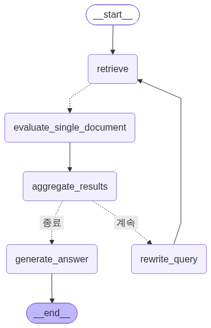

```python
from langgraph.graph import StateGraph, START, END
from IPython.display import Image, display

# 그래프 생성
workflow = StateGraph(HousingRagState)

# 노드 추가
workflow.add_node("retrieve", retrieve_documents)
workflow.add_node("evaluate_single_document", evaluate_single_document)
workflow.add_node("rewrite_query", rewrite_query)
workflow.add_node("generate_answer", generate_node_answer)
workflow.add_node("aggregate_results", aggregate_results)

workflow.add_edge(START, "retrieve")
# 조건부 엣지로 병렬 처리 설정
workflow.add_conditional_edges(
    "retrieve",  # 문서 검색 완료 후
    create_evaluation_workers,  # 조건부 엣지 함수
    ["evaluate_single_document"]  # 병렬 워커 노드
)
workflow.add_edge("evaluate_single_document", "aggregate_results")
workflow.add_conditional_edges(
    "aggregate_results",
    should_continue,
    {
        "계속": "rewrite_query",
        "종료": "generate_answer"
    }
)

workflow.add_edge("rewrite_query", "retrieve")
workflow.add_edge("generate_answer", END)

# 그래프 컴파일
housing_law_agent = workflow.compile()

# 그래프 시각화
display(Image(housing_law_agent.get_graph().draw_mermaid_png(max_retries=5, retry_delay=2.0)))
```

```python
inputs = {"question": "대리인과 아파트 임대차 계약을 체결할 때 주의해야 할 점은 무엇인가요?"}
for output in housing_law_agent.stream(inputs):
    for key, value in output.items():
        # 노드 출력
        pprint(f"Node '{key}':")
        pprint(f"Value: {value}", indent=2, width=80, depth=None)
    print("\n----------------------------------------------------------\n")
```

```
---주택임대차보호법 문서 검색---
---주택임대차보호법 관련 4개 문서에 대한 평가 병렬 워커 생성---
"Node 'retrieve':"
("Value: {'documents': [Document(id='761ab8fd-e65a-424e-84ff-801e5121a35f', "
 "metadata={'name': '주택임대차보호법', 'source': "
 "'data/housing_leasing_law.pdf'}, page_content='<출처>\\n다음 조항은 "
 '**주택임대차보호법**에서 발췌한 내용입니다.\\n</출처>\\n\\n<법률조항>\\n제3조의7(임대인의 정보 제시 '
 '의무) 임대차계약을 체결할 때 임대인은 다음 각 호의 사항을 임차인에게 제시하여야 한\\n다.\\n1. 제3조의6제3항에 따른 해당 '
 '주택의 확정일자 부여일, 차임 및 보증금 등 정보. 다만, 임대인이 임대차계약을 체결\\n하기 전에 제3조의6제4항에 따라 동의함으로써 '
 '이를 갈음할 수 있다.\\n2. 「국세징수법」 제108조에 따른 납세증명서 및 「지방세징수법」 제5조제2항에 따른 납세증명서. 다만, '
 '임대인이 임\\n대차계약을 체결하기 전에 「국세징수법」 제109조제1항에 따른 미납국세와 체납액의 열람 및 「지방세징수법」 '
 '제\\n6조제1항에 따른 미납지방세의 열람에 각각 동의함으로써 이를 갈음할 수 있다.\\n[본조신설 2023. 4. '
 "18.]\\n</법률조항>'), Document(id='05f73eee-111b-40fd-8b82-431b68cabb11', "
 "metadata={'source': 'data/housing_leasing_law.pdf', 'name': "
 "'주택임대차보호법'}, page_content='<출처>\\n다음 조항은 "
 '**주택임대차보호법**에서 발췌한 내용입니다.\\n</출처>\\n\\n<법률조항>\\n제6조의3(계약갱신 요구 등) '
 '① 제6조에도 불구하고 임대인은 임차인이 제6조제1항 전단의 기간 이내에 계약갱신을 요\\n구할 경우 정당한 사유 없이 거절하지 못한다. '
 '다만, 다음 각 호의 어느 하나에 해당하는 경우에는 그러하지 아니하\\n다.\\n1. 임차인이 2기의 차임액에 해당하는 금액에 이르도록 '
 '차임을 연체한 사실이 있는 경우\\n2. 임차인이 거짓이나 그 밖의 부정한 방법으로 임차한 경우\\n3. 서로 합의하여 임대인이 '
 '임차인에게 상당한 보상을 제공한 경우\\n4. 임차인이 임대인의 동의 없이 목적 주택의 전부 또는 일부를 전대(轉貸)한 경우\\n5. '
 '임차인이 임차한 주택의 전부 또는 일부를 고의나 중대한 과실로 파손한 경우\\n6. 임차한 주택의 전부 또는 일부가 멸실되어 임대차의 '
 '목적을 달성하지 못할 경우\\n7. 임대인이 다음 각 목의 어느 하나에 해당하는 사유로 목적 주택의 전부 또는 대부분을 철거하거나 '
 '재건축하기 위\\n하여 목적 주택의 점유를 회복할 필요가 있는 경우\\n가. 임대차계약 체결 당시 공사시기 및 소요기간 등을 포함한 철거 '
 '또는 재건축 계획을 임차인에게 구체적으로 고\\n지하고 그 계획에 따르는 경우\\n나. 건물이 노후ㆍ훼손 또는 일부 멸실되는 등 '
 '안전사고의 우려가 있는 경우\\n다. 다른 법령에 따라 철거 또는 재건축이 이루어지는 '
 '경우\\n\\x0c법제처                                                            '
 '5                                                       '
 '국가법령정보센터\\n주택임대차보호법\\n8. 임대인(임대인의 직계존속ㆍ직계비속을 포함한다)이 목적 주택에 실제 거주하려는 경우\\n9. '
 '그 밖에 임차인이 임차인으로서의 의무를 현저히 위반하거나 임대차를 계속하기 어려운 중대한 사유가 있는 경\\n우\\n② 임차인은 제1항에 '
 '따른 계약갱신요구권을 1회에 한하여 행사할 수 있다. 이 경우 갱신되는 임대차의 존속기간은\\n2년으로 본다.\\n③ 갱신되는 임대차는 '
 '전 임대차와 동일한 조건으로 다시 계약된 것으로 본다. 다만, 차임과 보증금은 제7조의 범위\\n에서 증감할 수 있다.\\n④ 제1항에 '
 '따라 갱신되는 임대차의 해지에 관하여는 제6조의2를 준용한다.\\n⑤ 임대인이 제1항제8호의 사유로 갱신을 거절하였음에도 불구하고 '
 '갱신요구가 거절되지 아니하였더라면 갱신되\\n었을 기간이 만료되기 전에 정당한 사유 없이 제3자에게 목적 주택을 임대한 경우 임대인은 '
 '갱신거절로 인하여 임\\n차인이 입은 손해를 배상하여야 한다.\\n⑥ 제5항에 따른 손해배상액은 거절 당시 당사자 간에 손해배상액의 '
 '예정에 관한 합의가 이루어지지 않는 한 다음\\n각 호의 금액 중 큰 금액으로 한다.\\n1. 갱신거절 당시 월차임(차임 외에 보증금이 '
 '있는 경우에는 그 보증금을 제7조의2 각 호 중 낮은 비율에 따라 월 단\\n위의 차임으로 전환한 금액을 포함한다. 이하 '
 '“환산월차임”이라 한다)의 3개월분에 해당하는 금액\\n2. 임대인이 제3자에게 임대하여 얻은 환산월차임과 갱신거절 당시 환산월차임 간 '
 '차액의 2년분에 해당하는 금액\\n3. 제1항제8호의 사유로 인한 갱신거절로 인하여 임차인이 입은 손해액\\n[본조신설 2020. 7. '
 "31.]\\n</법률조항>'), Document(id='7685412b-2ec6-4e3f-8cc0-f7da9c641e07', "
 "metadata={'source': 'data/housing_leasing_law.pdf', 'name': "
```

[output cut: 117 more lines]

````
 '임차인(대리인 포함)이 계약갱신을 요구할 경우 정당한 사유 없이 거절할 수 없으며, 정당한 거절 사유에는 2기 차임 연체, 거짓·부정한 '
 '방법 임차 등이 포함됩니다.  \\n  (출처: 주택임대차보호법 제6조의3)\\n\\n- **주택임대차보호법 제30조**  \\n  '
 '임대차계약은 법무부장관과 국토교통부장관이 협의하여 정한 표준계약서를 우선적으로 사용해야 하며, 당사자가 다른 서식을 합의한 경우에는 '
 '예외가 인정됩니다.  \\n  (출처: 주택임대차보호법 제30조)\\n\\n## 3. 추가 설명 또는 예시\\n- **대리인 신분 '
 '확인**  \\n  대리인이 계약을 체결할 경우, 위임장 등 적법한 대리권 증빙을 반드시 확인해야 하며, 임대차 조건과 계약갱신 권리, '
 '임대인의 거절 사유를 명확히 설명하고 서면으로 남기는 것이 중요합니다.\\n\\n- **확정일자 및 보증금 보호**  \\n  확정일자 '
 '부여일과 보증금, 차임 정보를 명확히 제시받아야 임차인의 권리 보호에 유리하며, 임대인이 이를 고의로 누락하거나 축소할 경우 법적 분쟁이 '
 '발생할 수 있습니다.\\n\\n- **계약서 작성 시 표준계약서 활용**  \\n  표준계약서를 사용하면 임대차 조건이 법률에 부합하는지 '
 '쉽게 확인할 수 있고, 분쟁 발생 시 법적 근거로 활용하기 용이합니다.\\n\\n## 4. 결론 및 요약\\n대리인과 아파트 임대차 '
 '계약을 체결할 때는 임대인의 정보 제공 의무(확정일자, 차임, 보증금, 납세증명서 등)를 반드시 확인하고, 계약갱신 요구권과 임대인의 '
 '정당한 거절 사유를 명확히 이해해야 합니다. 또한, 표준계약서 사용을 우선적으로 고려하며, 대리인의 적법한 권한 증빙을 철저히 확인하는 '
 '것이 중요합니다. 이를 통해 임차인의 권리 보호와 계약의 안정성을 확보할 수 있습니다.\\n\\n(출처: 주택임대차보호법 제3조의7, '
 "제6조의3, 제30조)\\n```'}")

----------------------------------------------------------
````

```python
# 마크다운 형식으로 출력
from IPython.display import Markdown
display(Markdown(value['node_answer']))
```

```
# 대리인과 아파트 임대차 계약 체결 시 주의사항

## 1. 질문에 대한 직접적인 답변
대리인과 아파트 임대차 계약을 체결할 때는 임대차계약 조건, 계약갱신 요구권, 임대인의 정당한 거절 사유를 명확히 확인해야 하며, 임대인은 임차인(대리인 포함)에게 확정일자 부여일, 차임 및 보증금 등의 정보를 반드시 제시해야 합니다. 또한, 임대인은 국세 및 지방세 납세증명서를 제시하거나 미납세 열람에 동의해야 하며, 계약서 작성 시에는 표준계약서 사용을 우선적으로 고려해야 합니다.

## 2. 관련 법률 조항 및 해석
- **주택임대차보호법 제3조의7**
  임대인은 임차인에게 확정일자 부여일, 차임, 보증금 등의 정보를 제공해야 하며, 국세 및 지방세 납세증명서 제시 의무가 있습니다. 다만, 임대인이 동의하면 이를 갈음할 수 있습니다.
  (출처: 주택임대차보호법 제3조의7)

- **주택임대차보호법 제6조의3**
  임대인은 임차인(대리인 포함)이 계약갱신을 요구할 경우 정당한 사유 없이 거절할 수 없으며, 정당한 거절 사유에는 2기 차임 연체, 거짓·부정한 방법 임차 등이 포함됩니다.
  (출처: 주택임대차보호법 제6조의3)

- **주택임대차보호법 제30조**
  임대차계약은 법무부장관과 국토교통부장관이 협의하여 정한 표준계약서를 우선적으로 사용해야 하며, 당사자가 다른 서식을 합의한 경우에는 예외가 인정됩니다.
  (출처: 주택임대차보호법 제30조)

## 3. 추가 설명 또는 예시
- **대리인 신분 확인**
  대리인이 계약을 체결할 경우, 위임장 등 적법한 대리권 증빙을 반드시 확인해야 하며, 임대차 조건과 계약갱신 권리, 임대인의 거절 사유를 명확히 설명하고 서면으로 남기는 것이 중요합니다.

- **확정일자 및 보증금 보호**
  확정일자 부여일과 보증금, 차임 정보를 명확히 제시받아야 임차인의 권리 보호에 유리하며, 임대인이 이를 고의로 누락하거나 축소할 경우 법적 분쟁이 발생할 수 있습니다.

- **계약서 작성 시 표준계약서 활용**
  표준계약서를 사용하면 임대차 조건이 법률에 부합하는지 쉽게 확인할 수 있고, 분쟁 발생 시 법적 근거로 활용하기 용이합니다.

## 4. 결론 및 요약
대리인과 아파트 임대차 계약을 체결할 때는 임대인의 정보 제공 의무(확정일자, 차임, 보증금, 납세증명서 등)를 반드시 확인하고, 계약갱신 요구권과 임대인의 정당한 거절 사유를 명확히 이해해야 합니다. 또한, 표준계약서 사용을 우선적으로 고려하며, 대리인의 적법한 권한 증빙을 철저히 확인하는 것이 중요합니다. 이를 통해 임차인의 권리 보호와 계약의 안정성을 확보할 수 있습니다.

(출처: 주택임대차보호법 제3조의7, 제6조의3, 제30조)
```

`(4) 웹 검색 기반 RAG 에이전트`

```python
# 웹 검색 도구
class SearchRagState(CorrectiveRagState):
    rewritten_query: str   # 재작성한 질문
    extracted_info: Annotated[List[InformationStrip], operator.add]  # 병렬 워커들로부터 여러 정보 조각을 수집
    processed_info: List[InformationStrip]  # 후처리된 결과용
    node_answer: Optional[str]
```

```python
def retrieve_documents(state: SearchRagState) -> dict:
    """웹 문서 검색 함수"""
    print("---웹 문서 검색---")
    query = state.get("rewritten_query", state["question"])
    docs = web_search.invoke(query)
    return {"documents": docs}

def create_evaluation_workers(state: SearchRagState):
    """각 웹 문서에 대해 평가 작업을 수행하는 병렬 워커를 생성하는 조건부 엣지 함수"""
    print(f"---{len(state['documents'])}개 웹 문서에 대한 평가 병렬 워커 생성---")

    # 각 문서에 대해 Send 객체를 생성하여 병렬 처리
    return [
        Send("evaluate_single_document", {
            "document": doc.page_content,
            "question": state["question"],
            "user_feedback": state.get("user_feedback", ""),  # 사용자 피드백이 있는 경우 전달
        })
        for doc in state["documents"]
    ]

def evaluate_single_document(state: DocumentWorkerState) -> dict:
    """단일 웹 문서를 처리하는 워커 함수"""
    print(f"---단일 웹 문서 처리 중 (길이: {len(state['document'][:100])}...)---")

    # 웹 검색에 특화된 프롬프트 템플릿
    extract_prompt = ChatPromptTemplate.from_messages([
        ("system", """당신은 인터넷 정보 검색 전문가입니다. 주어진 웹 문서에서 질문과 관련된 주요 사실과 정보를 3~5개 정도 추출하세요.

        웹 정보 추출 시 주의사항:
        - 신뢰할 수 있는 정보인지 판단하세요
        - 날짜가 명시된 정보는 시기를 포함하여 추출하세요
        - 통계나 수치 정보는 정확히 추출하세요
        - 출처 URL이나 사이트 정보를 포함하세요

        각 추출된 정보에 대해 다음 두 가지 측면을 0에서 1 사이의 점수로 평가하세요:
        1. 질문과의 관련성
        2. 답변의 충실성 (질문에 대한 완전하고 정확한 답변을 제공할 수 있는 정도)

        추출 형식:
        1. [추출된 정보]
        - 관련성 점수: [0-1 사이의 점수]
        - 충실성 점수: [0-1 사이의 점수]
        2. [추출된 정보]
        - 관련성 점수: [0-1 사이의 점수]
        - 충실성 점수: [0-1 사이의 점수]
        ...

        마지막으로, 추출된 정보를 종합하여 질문에 대한 전반적인 답변 가능성을 0에서 1 사이의 점수로 평가하세요."""),
        MessagesPlaceholder("user_feedback"),
        ("human", "<질문>\n{question}\n</질문>\n<웹 문서 내용>\n{document_content}\n</웹 문서 내용>")
    ])

    extract_llm = llm.with_structured_output(ExtractedInformation)

    try:
        extracted_data = extract_llm.invoke(extract_prompt.format(
            question=state["question"],
            document_content=state["document"],
            user_feedback=[("system", f"정보를 추출할 때 다음 사용자 피드백을 고려하세요:\n<피드백>{state.get('user_feedback', '')}</피드백>")] if "user_feedback" in state else []
        ))

        # 웹 정보의 품질 필터링 (조금 더 엄격)
        if extracted_data.query_relevance < 0.7:  # 웹 정보는 노이즈가 많으므로
            print(f"웹 문서 관련성이 낮음: {extracted_data.query_relevance}")
            return {"extracted_info": []}

        # 고품질 정보만 필터링
        high_quality_strips = [
            strip for strip in extracted_data.strips
            if strip.relevance_score > 0.6 and strip.faithfulness_score > 0.6  # 웹 정보 특성상 조금 낮춤
        ]

        print(f"고품질 웹 정보 {len(high_quality_strips)}개 추출됨")
        return {"extracted_info": high_quality_strips}

    except Exception as e:
        print(f"웹 문서 처리 중 오류 발생: {e}")
        return {"extracted_info": []}

def aggregate_results(state: SearchRagState) -> dict:
    """병렬 처리된 웹 검색 결과를 집계하는 함수"""
    print(f"---총 {len(state['extracted_info'])}개의 웹 정보 조각 집계---")

    if not state["extracted_info"]:
        return {
            "num_generations": state.get("num_generations", 0) + 1,
            "processed_info": []
        }

    # 1. LangChain EmbeddingsRedundantFilter를 사용한 의미적 중복 제거
    unique_info = remove_semantic_duplicates(
        state["extracted_info"],
        similarity_threshold=0.85  # 85% 이상 유사하면 중복으로 판단
    )

    # 2. 품질 점수에 따른 정렬
    sorted_info = sorted(
        unique_info,
        key=lambda x: (x.relevance_score + x.faithfulness_score) / 2,
        reverse=True
    )

    # 3. 상위 N개만 선택
    top_info = sorted_info[:10]  # 상위 10개만 유지

    print(f"최종 결과: {len(state['extracted_info'])} → {len(unique_info)}  → {len(top_info)}개")

    # 중요: extracted_info 키를 반환하지 않음 (reducer 중복 방지)
    return {
        "num_generations": state.get("num_generations", 0) + 1,
        "processed_info": top_info  # 후처리된 결과
    }

def rewrite_query(state: SearchRagState) -> dict:
    """웹 검색 쿼리 재작성 함수"""
    print("---웹 검색 쿼리 재작성---")

    rewrite_prompt = ChatPromptTemplate.from_messages([
        ("system", """당신은 인터넷 정보 검색 전문가입니다. 주어진 원래 질문과 추출된 웹 정보를 바탕으로, 더 관련성 있고 충실한 정보를 찾기 위해 검색 쿼리를 개선해주세요.

        웹 검색 쿼리 개선 가이드라인:
        1. 원래 질문의 핵심 키워드 유지
        2. 추출된 정보에서 부족한 부분 파악
        3. 시간적 맥락이 중요한 경우 연도 추가
        4. 구체적인 용어나 전문 용어 활용
        5. 검색 엔진 최적화를 고려한 키워드 조합

        다음 사항을 고려하여 검색 쿼리를 개선하세요:
        1. 원래 질문의 핵심 요소
        2. 추출된 정보의 관련성 점수
        3. 추출된 정보의 충실성 점수
        4. 부족한 정보나 더 자세히 알아야 할 부분

        개선된 검색 쿼리 작성 단계:
        1. 2-3개의 검색 쿼리를 제안하세요.
        2. 각 쿼리는 구체적이고 간결해야 합니다(5-15 단어 사이).
        3. 질문과 관련된 전문 용어를 적절히 활용하세요.
        4. 각 쿼리 뒤에는 해당 쿼리를 제안한 이유를 간단히 설명하세요.

        출력 형식:
        1. [개선된 검색 쿼리 1]
        - 이유: [이 쿼리를 제안한 이유 설명]
        2. [개선된 검색 쿼리 2]
        - 이유: [이 쿼리를 제안한 이유 설명]
        3. [개선된 검색 쿼리 3]
        - 이유: [이 쿼리를 제안한 이유 설명]

        마지막으로, 제안된 쿼리 중 가장 효과적일 것 같은 쿼리를 선택하고 그 이유를 설명하세요."""),
        MessagesPlaceholder("user_feedback"),
        ("human", "<원래 질문>\n{question}\n</원래 질문>\n<웹 문서 내용>\n{processed_info}\n<</웹 문서 내용>\n\n위 지침에 따라 개선된 웹 검색 쿼리를 작성해주세요.")
    ])

    processed_info_str = "\n".join([
        f"- {strip.content} (출처: {strip.source})"
        for strip in state["processed_info"]
    ])

    rewrite_llm = llm.with_structured_output(RefinedQuestion)

    response = rewrite_llm.invoke(rewrite_prompt.format(
        question=state["question"],
        processed_info=processed_info_str,
        user_feedback=[("system", f"쿼리를 재작성할 때 다음 사용자 피드백을 고려하세요:\n<피드백>{state.get('user_feedback', '')}</피드백>")] if "user_feedback" in state else []
    ))

    return {"rewritten_query": response.question_refined}

def generate_node_answer(state: SearchRagState) -> dict:
    """웹 검색 결과 기반 답변 생성 함수"""
    print("---웹 검색 기반 답변 생성---")

    answer_prompt = ChatPromptTemplate.from_messages([
        ("system", """당신은 인터넷 정보 검색 전문가입니다. 주어진 질문과 웹에서 추출된 정보를 바탕으로 신뢰할 수 있는 답변을 생성해주세요.

        웹 정보 기반 답변 작성 가이드라인:
        - 여러 출처의 정보를 종합하여 균형잡힌 답변 제공
        - 정보의 신뢰도와 출처를 명확히 표시
        - 상충되는 정보가 있다면 명시
        - 정보의 시점이나 업데이트 날짜 고려
        - 추가 검증이 필요한 정보는 명시

        답변은 마크다운 형식으로 작성하며, 각 정보의 출처를 명확히 표시해야 합니다.
        답변 구조:
        1. 질문에 대한 직접적인 답변 요약
        2. 상세 설명 (웹 정보 기반)
        3. 관련 출처 및 링크
        4. 주의사항 또는 추가 고려사항 (있는 경우)
        5. 결론 및 요약

        각 섹션에서 사용된 정보의 출처를 괄호 안에 명시하세요.
        예: (출처: 네이버 뉴스, 2024.01.15) 또는 (출처: 위키피디아)"""),
        MessagesPlaceholder("user_feedback"),
        ("human", "<질문>\n{question}\n</질문>\n<웹에서 추출된 정보>\n{processed_info}\n</웹에서 추출된 정보>\n\n위 지침에 따라 신뢰할 수 있는 최종 답변을 작성해주세요.")
    ])

    # 웹 정보를 더 상세하게 포맷팅
    processed_info_str = "\n---\n".join([
        f"**내용**: {strip.content}\n"
        f"**출처**: {strip.source}\n"
        f"**신뢰도**: 관련성 {strip.relevance_score:.2f}, 충실성 {strip.faithfulness_score:.2f}"
        for strip in state["processed_info"]
    ])

    node_answer = llm.invoke(answer_prompt.format(
        question=state["question"],
        processed_info=processed_info_str,
        user_feedback=[("system", f"답변을 생성할 때 다음 사용자 피드백을 고려하세요:\n<피드백>{state.get('user_feedback', '')}</피드백>")] if "user_feedback" in state else []
    ))

    return {"node_answer": node_answer.content}

def should_continue(state: SearchRagState) -> Literal["계속", "종료"]:
    """웹 검색 계속 여부 결정 함수"""
    print(f"현재 생성 횟수: {state['num_generations']}, 추출된 웹 정보 수: {len(state['processed_info'])}")

    # 웹 검색은 정보가 많으므로 조건을 조정
    if state["num_generations"] >= 2:  # 최대 2번 재시도
        return "종료"

    if len(state["processed_info"]) > 0:  # 웹 정보가 1개 이상이면 충분
        return "종료"

    return "계속"
```